# Section 3 (Team-Apogee) Assignment-5

## Reference

### https://www.hackerearth.com/practice/machine-learning/machine-learning-algorithms/logistic-regression-analysis-r/practice-problems/machine-learning/how-severe-can-an-airplane-accident-be-03e7a3f1/

### This data set designed to anticipate and classify the severity of any airplane accident based on past incidents. With this, all airlines, aviation industry, can predict the severity of airplane accidents caused due to various factors and, correspondingly, have a plan of action to minimize the risk associated with them.

## Features

### Accident_ID : unique id assigned to each row

### Accident_Type_Code : the type of accident (factor, not numeric)

### Cabin_Temperature : the last recorded temperature before the incident, measured in degrees fahrenheit

### Turbulence_In_gforces :the recorded/estimated turbulence experienced during the accident

### Control_Metric : an estimation of how much control the pilot had during the incident given the factors at play

### Total_Safety_Complaints : number of complaints from mechanics prior to the accident

### Days_Since_Inspection : how long the plane went without inspection before the incident

### Safety_Score : a measure of how safe the plane was deemed to be

### Violations ; number of violations that the aircraft received during inspections

### Severity(target) : a description (4 level factor) on the severity of the crash

```
                   Minor_Damage_And_Injuries
                   Highly_Fatal_And_Damaging
                   Significant_Damage_And_Serious_Injuries
                   Significant_Damage_And_Fatalities
```

```python
#load libraries
import numpy as np
import pandas as pd
import warnings
warnings.simplefilter("ignore")
import matplotlib.pyplot as plt
from imblearn.over_sampling import SMOTE
import seaborn as sns
from sklearn.preprocessing import StandardScaler
import plotly.express as px
from sklearn.model_selection import train_test_split
from sklearn.neighbors import KNeighborsClassifier
from sklearn.tree import DecisionTreeClassifier
from sklearn.metrics import confusion_matrix,recall_score,precision_score,f1_score,accuracy_score,classification_report
from sklearn.tree import plot_tree
from sklearn.model_selection import KFold
from sklearn import tree
from sklearn.model_selection import train_test_split, cross_val_score, GridSearchCV
from xgboost import XGBClassifier
from sklearn.multiclass import OneVsRestClassifier
from sklearn.ensemble import RandomForestClassifier,AdaBoostClassifier,GradientBoostingClassifier
```

```python
#load data
air=pd.read_csv('D:/Python/Dataset/Airplane.csv')
```

```python
air.head(5)
```

|  | Severity | Safety_Score | Days_Since_Inspection | Total_Safety_Complaints | Control_Metric | Turbulence_In_gforces | Cabin_Temperature | Accident_Type_Code | Max_Elevation | Violations | Adverse_Weather_Metric | Accident_ID |
| --- | --- | --- | --- | --- | --- | --- | --- | --- | --- | --- | --- | --- |
| 0 | Minor_Damage_And_Injuries | 49.223744 | 14 | 22 | 71.285324 | 0.272118 | 78.04 | 2 | 31335.476824 | 3 | 0.424352 | 7570 |
| 1 | Minor_Damage_And_Injuries | 62.465753 | 10 | 27 | 72.288058 | 0.423939 | 84.54 | 2 | 26024.711057 | 2 | 0.352350 | 12128 |
| 2 | Significant_Damage_And_Fatalities | 63.059361 | 13 | 16 | 66.362808 | 0.322604 | 78.86 | 7 | 39269.053927 | 3 | 0.003364 | 2181 |
| 3 | Significant_Damage_And_Serious_Injuries | 48.082192 | 11 | 9 | 74.703737 | 0.337029 | 81.79 | 3 | 42771.499200 | 1 | 0.211728 | 5946 |
| 4 | Significant_Damage_And_Fatalities | 26.484018 | 13 | 25 | 47.948952 | 0.541140 | 77.16 | 3 | 35509.228515 | 2 | 0.176883 | 9054 |

```python
air.Severity.value_counts()
```

```
Highly_Fatal_And_Damaging                  3049
Significant_Damage_And_Serious_Injuries    2729
Minor_Damage_And_Injuries                  2527
Significant_Damage_And_Fatalities          1695
Name: Severity, dtype: int64
```

```python
ord_dic={'Minor_Damage_And_Injuries':1,'Highly_Fatal_And_Damaging':2,'Significant_Damage_And_Serious_Injuries':3,
           'Significant_Damage_And_Fatalities':4}
```

```python
 air['Severity'].replace(ord_dic,inplace=True)
```

```python
#Changing Data types
cat_cols=['Severity','Accident_Type_Code','Violations']
cont_cols=['Safety_Score','Days_Since_Inspection','Total_Safety_Complaints','Control_Metric',
           'Turbulence_In_gforces','Cabin_Temperature','Max_Elevation','Adverse_Weather_Metric']
```

```python
air[cat_cols] = air[cat_cols].apply(lambda x: x.astype('category'))
air[cont_cols] = air[cont_cols].apply(lambda x: x.astype('float'))
```

air.info()

### Removing unwanted Columns

```python
air.drop(columns='Accident_ID',inplace=True)
```

## Creating Dummies

```python
num_data = air.loc[:,cont_cols]
cat_data = air.loc[:,cat_cols]
```

```python
cat_data = pd.get_dummies(cat_data,columns=['Accident_Type_Code','Violations'],drop_first=True)
```

```python
cat_data
```

|  | Severity | Accident_Type_Code_2 | Accident_Type_Code_3 | Accident_Type_Code_4 | Accident_Type_Code_5 | Accident_Type_Code_6 | Accident_Type_Code_7 | Violations_1 | Violations_2 | Violations_3 | Violations_4 | Violations_5 |
| --- | --- | --- | --- | --- | --- | --- | --- | --- | --- | --- | --- | --- |
| 0 | 1 | 1 | 0 | 0 | 0 | 0 | 0 | 0 | 0 | 1 | 0 | 0 |
| 1 | 1 | 1 | 0 | 0 | 0 | 0 | 0 | 0 | 1 | 0 | 0 | 0 |
| 2 | 4 | 0 | 0 | 0 | 0 | 0 | 1 | 0 | 0 | 1 | 0 | 0 |
| 3 | 3 | 0 | 1 | 0 | 0 | 0 | 0 | 1 | 0 | 0 | 0 | 0 |
| 4 | 4 | 0 | 1 | 0 | 0 | 0 | 0 | 0 | 1 | 0 | 0 | 0 |
| ... | ... | ... | ... | ... | ... | ... | ... | ... | ... | ... | ... | ... |
| 9995 | 3 | 0 | 0 | 0 | 1 | 0 | 0 | 0 | 1 | 0 | 0 | 0 |
| 9996 | 2 | 0 | 0 | 1 | 0 | 0 | 0 | 0 | 1 | 0 | 0 | 0 |
| 9997 | 3 | 0 | 1 | 0 | 0 | 0 | 0 | 0 | 0 | 1 | 0 | 0 |
| 9998 | 1 | 0 | 0 | 0 | 1 | 0 | 0 | 0 | 1 | 0 | 0 | 0 |
| 9999 | 2 | 0 | 0 | 0 | 1 | 0 | 0 | 0 | 1 | 0 | 0 | 0 |

10000 rows × 12 columns

### Combining categorical and Comtinuous Data

```python
#combine categorical and numerical data
data = pd.concat([num_data,cat_data],axis=1)
```

```python
#differentiating x,y variables
x = data.drop("Severity",axis=1)
y = data["Severity"]
```

### Treatment of Imbalanced Data

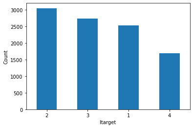

```python
y.value_counts().plot(kind='bar', xlabel='Itarget', ylabel='Count', rot=0)
```

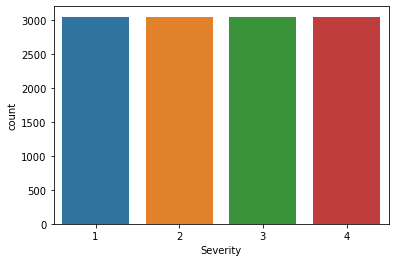

```python
#using smote to balance the data
smote = SMOTE(random_state =300)
X_smote, Y_smote = smote.fit_resample(x,y)
sns.countplot(Y_smote)
```

## Train Test Split

```python
x_train, x_validation, y_train, y_validation = train_test_split(X_smote, Y_smote, test_size=0.3,random_state=1)
```

```python
print(x_train.shape)
print(x_validation.shape)
print(y_train.shape)
print(y_validation.shape)
```

```
(8537, 19)
(3659, 19)
(8537,)
(3659,)
```

### Standardizing Variables

```python
scaler = StandardScaler()
scaler.fit(x_train)

# Transform the predictors of training and validation sets
train_predictors = scaler.transform(x_train) # train_predictors is not a numpy array
train_target = y_train # train_target is now a series object

validation_predictors = scaler.transform(x_validation) # validation_target is now a series object
validation_target = y_validation # validation_target is now a series object
```

### Encoding the Target Variable

```python
from sklearn.preprocessing import LabelEncoder
label_encoder= LabelEncoder()
validation_target= label_encoder.fit_transform(validation_target)
```

```python
from sklearn.metrics import f1_score, make_scorer
f1macro = make_scorer(f1_score , average='macro')
```

### KNN

```python
knn = KNeighborsClassifier(n_neighbors=5,  metric='euclidean') # user euclidean distance

# We could choose other distance metrics; for a list of other metrics...
# https://scikit-learn.org/stable/modules/generated/sklearn.metrics.pairwise.distance_metrics.html#sklearn.metrics.pairwise.distance_metrics
# coverage of difference distance metrics is outside of this courses scope... but, you can experiment by changing the metric

knn.fit(validation_predictors,validation_target)
knn_prediction_output = knn.predict(validation_predictors)
knn_prediction_output
accuracy_score(validation_target,knn_prediction_output,normalize=True)
```

```
0.7392730254167805
```

### Hyper Parameter Tuning KNN

```python
## #List Hyperparameters that we want to tune.

leaf_size = list(range(1,50))
n_neighbors = list(range(1,30))
p=[1,2]
#Convert to dictionary
hyperparameters = dict(leaf_size=leaf_size, n_neighbors=n_neighbors, p=p)
#Create new KNN object
knn_2 = KNeighborsClassifier()
#Use GridSearch
clf = GridSearchCV(knn_2, hyperparameters, cv=10,n_jobs=-1,scoring=f1macro)
#Fit the model
best_model = clf.fit(validation_predictors,validation_target)
#Print The value of best Hyperparameters
print('Best leaf_size:', best_model.best_estimator_.get_params()['leaf_size'])
print('Best p:', best_model.best_estimator_.get_params()['p'])
print('Best n_neighbors:', best_model.best_estimator_.get_params()['n_neighbors'])
```

```
Best leaf_size: 1
Best p: 1
Best n_neighbors: 3
```

```python
y_pred=best_model.predict(validation_predictors)
```

```python
print(accuracy_score(validation_target,y_pred))
```

```
0.7993987428259087
```

```python
print(classification_report(validation_target,y_pred))
```

```
              precision    recall  f1-score   support

           1       0.69      0.86      0.76       905
           2       0.84      0.77      0.80       908
           3       0.83      0.77      0.80       912
           4       0.87      0.80      0.84       934

    accuracy                           0.80      3659
   macro avg       0.81      0.80      0.80      3659
weighted avg       0.81      0.80      0.80      3659
```

#### Interpretation of KNN: The value of accuracy score in KNN classifier hass been improved from 73% to 80 %.

### Random Forest

```python
classifier = RandomForestClassifier(n_estimators = 10, criterion = 'entropy', random_state = 42)
classifier.fit(validation_predictors,validation_target)
```

```
RandomForestClassifier(criterion='entropy', n_estimators=10, random_state=42)
```

```python
y_pred = classifier.predict(validation_predictors)
print(accuracy_score(validation_target,y_pred))
```

```
0.9964471166985516
```

### Hyper Parameter Tuning of Random Forest

```python
## Hyper Parameter Optimization

rd_grid = {'n_estimators': [10,20],
              'max_depth': range(2,20,1),
              'max_features': ['auto', 'sqrt', None],
              'min_samples_split': range(1,10,2),
              'min_samples_leaf': range(2,10,2),
              'criterion': ['gini', 'entropy']}
```

```python
classifier = RandomForestClassifier()
```

```python
rf_search=GridSearchCV(estimator=classifier, param_grid=rd_grid, cv=10,n_jobs=-1,scoring=f1macro)
```

```python
rf_model=rf_search.fit(validation_predictors,validation_target)
```

```python
y_pred = rf_model.predict(validation_predictors)
```

```python
print(accuracy_score(validation_target, y_pred))
```

```
0.9877015578026783
```

### Interpretation Random forest results: Without hyper parametrization the results of the Random forest is :99.64%

### After hyper parametrizaation the results are : 98.77% ,the results are slightly decreased in terms of accuracy.

## Decision tree

```python
dt = DecisionTreeClassifier(max_depth=3)
dt.fit(validation_predictors,validation_target)
```

```
DecisionTreeClassifier(max_depth=3)
```

```python
y_pred = dt.predict(validation_predictors)
```

```python
print(accuracy_score(validation_target, y_pred))
```

```
0.4963104673408035
```

### Hyper Parameter Tuning With Decision Tree

```python
#Hyper Parametere tuning

# Create the parameter grid based on the results of random search
params = {
    'max_depth': [2, 3, 5, 10, 20],
    'min_samples_leaf': [5, 10, 20, 50, 100],
    'criterion': ["gini", "entropy"]
}
```

```python
grid_search = GridSearchCV(estimator=dt,
                           param_grid=params,
                           cv=4, n_jobs=-1, verbose=1, scoring = f1macro)
```

```python
best_dt=grid_search.fit(validation_predictors,validation_target)
```

```
Fitting 4 folds for each of 50 candidates, totalling 200 fits
```

```python
print(grid_search.best_estimator_)
```

```
DecisionTreeClassifier(criterion='entropy', max_depth=10, min_samples_leaf=5)
```

```python
y_pred=best_dt.predict(validation_predictors)
```

```python
print(f"{'Accuracy Score: ':18}{accuracy_score(validation_target, y_pred)}")
```

```
Accuracy Score:   0.9368679967204154
```

### InterPrettion of the results of Decision tree: The results of the Decision tree without hyperparammetrization are 49.63%

### After using the HyperParameterization the results are significantly improved to :93.6%,with the best paramters { criterion='entropy', max_depth=10, min_samples_leaf=5 }

### XGBOOST

```python
xgboost = XGBClassifier()
xgboost.fit(validation_predictors,validation_target)
```

```
XGBClassifier(base_score=0.5, booster='gbtree', callbacks=None,
              colsample_bylevel=1, colsample_bynode=1, colsample_bytree=1,
              early_stopping_rounds=None, enable_categorical=False,
              eval_metric=None, gamma=0, gpu_id=-1, grow_policy='depthwise',
              importance_type=None, interaction_constraints='',
              learning_rate=0.300000012, max_bin=256, max_cat_to_onehot=4,
              max_delta_step=0, max_depth=6, max_leaves=0, min_child_weight=1,
              missing=nan, monotone_constraints='()', n_estimators=100,
              n_jobs=0, num_parallel_tree=1, objective='multi:softprob',
              predictor='auto', random_state=0, reg_alpha=0, ...)
```

```python
y_pred = xgboost.predict(validation_predictors)
```

```python
print(accuracy_score(validation_target, y_pred))
```

```
1.0
```

### Hyper Parameter Tuning XGBOOST

```python
# Criterion used to guide data splits

# Create the random grid
param_grid_random = {
    "n_estimators" : [100, 200, 500],
    "max_depth" : [3, 6, 9],
    "gamma" : [0.01, 0.1],
    "learning_rate" : [0.001, 0.01, 0.1, 1]
}

xgboost = XGBClassifier()
xgb_search=GridSearchCV(estimator=xgboost, param_grid=param_grid_random, cv=3,n_jobs=-1,scoring=f1macro)
best_xgb=xgb_search.fit(validation_predictors,validation_target)
```

[output not shown]

### Note:due to wrong variable the error occured to show the best pararmeter,now the code is copied to

### the below cell,and we didn't ran the cell again due to high computaional cost,but the model is trained and fit to the validators.The code is executing without errors now.

```python
print(xgb_search.best_estimator_)
y_pred=best_xgb.predict(validation_predictors)
print(f"{'Accuracy Score: ':18}{accuracy_score(validation_target, y_pred)}")
```

```
XGBClassifier(base_score=0.5, booster='gbtree', callbacks=None,
              colsample_bylevel=1, colsample_bynode=1, colsample_bytree=1,
              early_stopping_rounds=None, enable_categorical=False,
              eval_metric=None, gamma=0.1, gpu_id=-1, grow_policy='depthwise',
              importance_type=None, interaction_constraints='',
              learning_rate=0.1, max_bin=256, max_cat_to_onehot=4,
              max_delta_step=0, max_depth=6, max_leaves=0, min_child_weight=1,
              missing=nan, monotone_constraints='()', n_estimators=500,
              n_jobs=0, num_parallel_tree=1, objective='multi:softprob',
              predictor='auto', random_state=0, reg_alpha=0, ...)
Accuracy Score:   1.0
```

### Interepretation of XGBOOST:The results of XGBOOST without hyper parameters and with hyper parameter is same ,the model is overfiiting in both the cases.

### ADABOOST Classifier

```python
abc = AdaBoostClassifier(random_state=10)
```

```python
ada_model = abc.fit(validation_predictors,validation_target)
```

```python
y_pred = ada_model.predict(validation_predictors)
```

```python
print(f"{'Accuracy Score: ':18}{accuracy_score(validation_target, y_pred)}")
```

```
Accuracy Score:   0.52965291063132
```

### ADABOOST Hyper Parameter Tuning

```python
# Criterion used to guide data splits

# Create the random grid
param_grid_random = {
    "n_estimators" : [100, 200, 300],
    "learning_rate" : [0.001, 0.01, 0.1, 1]
}

abc = AdaBoostClassifier(random_state=10)
ada_search=GridSearchCV(estimator=abc, param_grid=param_grid_random, cv=3,n_jobs=-1,scoring=f1macro)
best_abc=ada_search.fit(validation_predictors,validation_target)
```

```python
print(ada_search.best_estimator_)
y_pred=best_abc.predict(validation_predictors)
print(f"{'Accuracy Score: ':18}{accuracy_score(validation_target, y_pred)}")
```

```
AdaBoostClassifier(learning_rate=0.1, n_estimators=100, random_state=10)
Accuracy Score:   0.5930582126264007
```

### Interpretation: The results of ADABOOST shows that the Hyper parameterization has improved the accuracy of the model,the accuracy is improved from 53 % to 59% with the parameters{ learning_rate=0.1, n_estimators=100, random_state=10}

### Gradient Boosting

```python
gboost = GradientBoostingClassifier(random_state=15)
```

```python
_ = gboost.fit(validation_predictors,validation_target)
```

```python
y_pred = gboost.predict(validation_predictors)
```

```python
print(f"{'Accuracy Score: ':18}{accuracy_score(validation_target, y_pred)}")
```

```
Accuracy Score:   0.9027056572834108
```

#### Hyper Parameter Tuning Gradient Boosting

```python
# Criterion used to guide data splits

# Create the random grid
param_grid_gboost = {
    "n_estimators" : [100, 200, 500],
    "max_depth" : [3, 6, 9],
    "learning_rate" : [0.001, 0.01, 0.1, 1]
}
gboost = GradientBoostingClassifier(random_state=15)
gb_search = GridSearchCV(estimator = gboost,param_grid=param_grid_gboost, cv=3,n_jobs=-1,scoring=f1macro)
best_gsearch=gb_search.fit(validation_predictors,validation_target)
```

```python
print(gb_search.best_estimator_)
y_pred=best_gsearch.predict(validation_predictors)
print(f"{'Accuracy Score: ':18}{accuracy_score(validation_target, y_pred)}")
```

```
GradientBoostingClassifier(max_depth=9, n_estimators=200, random_state=15)
Accuracy Score:   1.0
```

### Interpretation: The Gradient boosting accuracy has been improved or we can say it has become overfitted after the hyper parametrization

### the accuracy was 90% before and then become 100%.By using differnt parameters we can control the overfitting of the model.

## Recommended Model: For our dataset we will take Random forest classifier, because as per the data set the accuracy is good not overfitted..